# Discrete-Time Hazards

Author

Affiliation

Dave Clark

Binghamton University

Published

September 13, 2026

# Goals

We’ve spent a lot of time on the binomial model predicting interstate disputes, but have not thought about the possibility that how long a dyad has been at peace might influence the value of the $y$ variable in the next period. Put differently, we haven’t considered the possibility of “memory” across time. This week, we’ll examine:

- What would **memory** look like in a binary time-series setting, and why doesn’t the logit have any?
- The concepts underneath hazard models: failure, survival, censoring, spells, and the **hazard rate**.
- The **discrete-time hazard model** — which turns out to be a logit you already know how to estimate, with one thing added to the right-hand side.

We continue using the Oneal and Russett (1997) democratic peace data. In part, this is for familiarity, using the same $y$, and mostly the same model as last week’s diagnostics deck. It is also the setting in which the discrete hazards argument was originally made: Beck, Katz, and Tucker (1998) built their case on these very data. Later in the slides, we’ll apply the same machinery to a second dataset — leader tenure — where the spells are shaped somewhat differently.

# Temporal dependence

So far we have looked at binary-response models in terms of the log-likelihood, estimation, and interpretation. Today we relax an assumption every one of those models has made without saying so: **temporal independence**.

Temporal independence requires that $cov(\varepsilon_t, \varepsilon_{t-k}) = 0$ — that the errors are uncorrelated across time. It implies observations on $y$ are independent of one another. Put differently, the process generating $y$ is *memoryless*.

## Memory in models

In the linear model we had several ways of letting today’s $y$ depend on the past — lagged $y$, lagged $x$. In the binary model we want the same kind of dynamics, but lagging $y$ does not quite do it. A lagged $y$ measures whether the *event* happened last period. What we actually want is how the latent probability that $y=1$ in the past bears on the probability $y=1$ today.

## The baseline model

Here is the model from last week, unchanged.

```r
dpm1 <- glm(dispute ~ border + deml + lncaprat + ally,
            family = binomial(link = "logit"), data = dp)

modelsummary(dpm1,
             stars = TRUE,
             coef_rename = c("border" = "Shared border",
                             "deml"   = "Min. democracy",
                             "lncaprat" = "Capabilities ratio (log)",
                             "ally"   = "Allied"),
             gof_omit = "RMSE|F",
             title = "The memoryless dispute model, Oneal-Russett dyad-years.",
             notes = "No measure of time appears anywhere in it.")
```

The memoryless dispute model, Oneal-Russett dyad-years.

|  | (1) |
| --- | --- |
| (Intercept) | -2.987*** |
|  | (0.107) |
| Shared border | 1.036*** |
|  | (0.088) |
| Min. democracy | -0.070*** |
|  | (0.007) |
| Capabilities ratio (log) | -0.227*** |
|  | (0.024) |
| Allied | -0.842*** |
|  | (0.081) |
| Num.Obs. | 20990 |
| AIC | 7024.3 |
| BIC | 7064.1 |
| Log.Lik. | -3507.152 |

+ p < 0.1, * p < 0.05, ** p < 0.01, *** p < 0.001  
No measure of time appears anywhere in it.

But here’s a question this model can’t answer: **What is the effect of democracy on a dyad that has been at peace for two years? For twenty-two?**

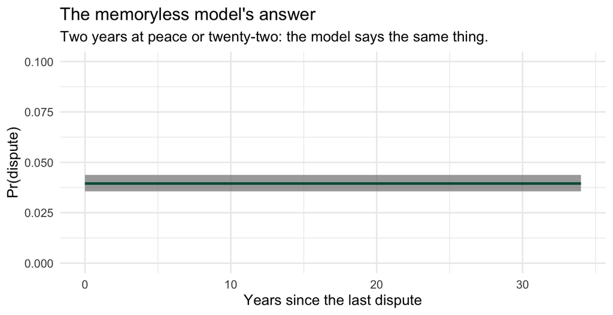

Figure 1

```r
nd <- tibble(stime = 0:34, border = 0, deml = median(dp$deml),
             lncaprat = median(dp$lncaprat), ally = 0)

pred <- bind_cols(nd, predict(dpm1, newdata = nd, type = "link", se.fit = TRUE)) %>%
  mutate(p  = plogis(fit),
         lb = plogis(fit - 1.96 * se.fit),
         ub = plogis(fit + 1.96 * se.fit))

ggplot(pred, aes(stime, p)) +
  geom_ribbon(aes(ymin = lb, ymax = ub), fill = bu_greyfill, alpha = 0.7) +
  geom_line(color = bu_green, linewidth = 1) +
  scale_y_continuous(limits = c(0, 0.10)) +
  labs(title = "The memoryless model's answer",
       subtitle = "Two years at peace or twenty-two: the model says the same thing.",
       x = "Years since the last dispute", y = "Pr(dispute)") +
  theme_bu()
```

The prediction line over time is flat, and it is flat *by construction*. Time since the last dispute is not in the model, so it cannot matter: by exclusion, $\widehat{\beta}$ on time is fixed at zero. A dyad two years past a dispute and a dyad twenty-two years past one are treated as identical observations differing only in $X$.

Notice this is a choice we made in specifying the model. We assumed $y_t$ has no bearing on $y_{t+1}$ — no persistence, no memory from period to period. The rest of this lecture is about a class of models built to ask the question that assumption rules out: **how does having survived until now affect the chances of failing now?**

**Where this connects to last week**

The democratic peace data are panel data — cross-sections observed over time — and last week that structure caused us trouble. When we added dyad fixed effects, 621 of 827 dyads turned out never to experience a dispute, and every one of them was perfectly predicted by its own dummy. We treated that as a pathology, which it was. But it is also a *description of the data*: for most dyads, $y$ is a long string of zeros occasionally punctuated by a one. That structure is part of why it seems important to think about “memory” or “persistence” over time.

# Hazards

The **hazard** is the probability of failure at a particular point in time, *conditional on having survived up until that point*. Asking about the chances that something ends without asking how long it has already lasted usually does not make much sense.

Consider human mortality as an example. All else equal:

- What is the probability of death for a 2-year-old?
- For a 22-year-old?
- For a 92-year-old?

It’s possible (likely?) these probabilities are all similar because we’re asking the wrong question. We’re considering all these probabilities unconditionally even though a potentially important condition is that:

- The 2 year old has survived up until 2.
- The 22 year old has survived up until 22.
- The 92 year old has survived up until 92.

That conditional probability,

$$Pr(\text{Fail}_t \mid \text{Survival}_{t-1}),$$

is the **hazard rate**.

## Two ways to think about time

This invites us to think about how long the **spell** is a unit survives before it fails.

What do data on spells look like? There are two basic forms.

Survival:

$$\text{Age} = 1, 2, 3, 4, 5, \ldots, 87, 88, 89$$

and failure:

$$\text{Death} = 0, 0, 0, 0, 0, \ldots, 0, 0, 1$$

These carry the two halves of the hazard — how many periods the unit survives, and the period in which it fails. They also correspond to the two families of hazard model. To keep them straight, ask yourself **what one row of your data is, and what the dependent variable on that row measures.**

**Continuous-time models: one row per spell, and $y$ is the survival time.** The leader is the row, and the $y$ variable is “held office for eleven years.” That is the first vector above. We’ll cover continuous-time models in November.

**Discrete-time models: one row per period, and $y$ is the failure indicator.** The leader-*year* is the row, and the $y$ variable is “did this leader leave office during this year — yes or no.” That is the second vector, and because $y$ is binary we can estimate it with a binomial log-likelihood, which is to say with a logit.

So the same eleven-year tenure is one row in one setup and eleven rows in the other. That is a reshaping of the same facts, not two different studies, and the section on BTSCS data below is about how to do the reshaping.

### The process is continuous; the measurement is not

Here is the distinction - it’s easy to confuse the two. Leaders do not leave office on the first of January. A leader can fall at any hour of any day, and a dispute can start on a Tuesday afternoon — **the process runs in continuous time.** But Archigos writes down a year, and Oneal and Russett write down a year, so **what we get to observe is an interval.** The process is continuous and the record is chunked.

Which means the choice between the two families is usually not a choice about the world. It is a choice about the data you were handed. If the record gives you exact dates, you can use them; if it gives you years, you have interval data whether you like it or not, and pretending otherwise does not make the information appear.

Two things follow.

**Wide intervals matter more when a lot happens inside them.** If the chance of failing in a period is small, it barely matters that we cannot see *where* in the period the failure fell. If the chance is large, it matters more. Our two datasets sit on either side of this: the annual chance of a dispute is about **4.5%**, while the annual chance of a leader losing office is about **19%** — four times higher.

**Chunked measurement produces ties, in bulk.** Because tenure is recorded in whole years, survival time takes very few distinct values, and enormous numbers of leaders share each one. In these data **2,996 exits are spread over just 46 distinct survival times — 65 leaders to a value on average, and 710 of them leaving in their very first year.** For a continuous-time model, these “ties” are a nuisance to be worked around, and in November we will see the approximations people use to do it. For a discrete-time model it is not a problem at all: grouped failures are what the model assumes in the first place. When the data come to you in years, the discrete-time model is the one that takes them at face value.

**An aside on naming**

Models like these are called hazard models, survival models, duration models, or event-history models more or less interchangeably. They all mean modeling the time until an event. The names sometimes signal which quantity is in view: the hazard is the probability of failure at $t$; survival is the probability of lasting *past* $t$. They are opposites. “Event history” usually signals discrete time.

## What spells actually look like

Figure 2 shows spells in the dispute data (left panel) and the Archigos leader survival data (right panel). Notice that spells can end in two ways. The unit can fail by experiencing the event of interest (a dispute, leaving office), or the unit can survive through the end of the observation period - it is **censored**. Each bar is one spell, starting at zero and running to the length we observe; a filled dot means the spell **ended** and a cross means it’s **censored**.[^1]

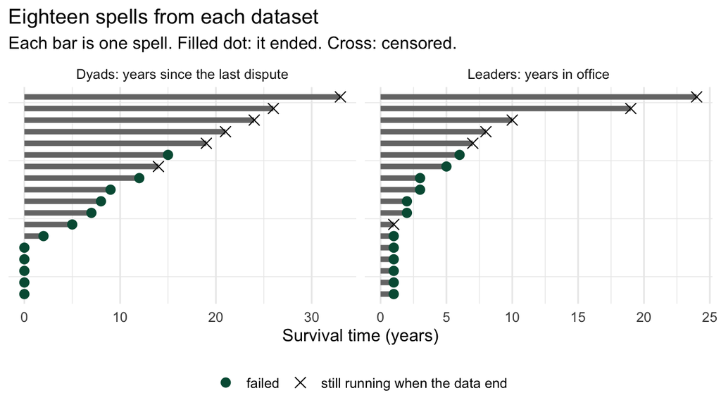

Figure 2

```r
set.seed(20260916)   # the spells below are a random draw; fix it so the figure is stable

pick <- function(d, nf, nc) bind_rows(
  d %>% dplyr::filter(fail == 1) %>% slice_sample(n = nf),
  d %>% dplyr::filter(fail == 0) %>% slice_sample(n = nc))

# the spell counter is built properly in a moment; here it is inline, from dp
dp_sp <- dp %>% arrange(dyad, year) %>%
  group_by(dyad) %>%
  mutate(prior = lag(dispute, default = 1), spell = cumsum(prior == 1)) %>%
  group_by(dyad, spell) %>%
  summarise(len = n() - 1, fail = as.integer(any(dispute == 1)), .groups = "drop") %>%
  pick(12, 6) %>% arrange(len) %>%
  mutate(row = row_number(), data = "Dyads: years since the last dispute")

lt_sp <- lt %>% group_by(obsid) %>%
  summarise(len = max(t), fail = max(leftoffice), .groups = "drop") %>%
  pick(12, 6) %>% arrange(len) %>%
  mutate(row = row_number(), data = "Leaders: years in office")

bind_rows(dp_sp %>% dplyr::select(row, len, fail, data),
          lt_sp %>% dplyr::select(row, len, fail, data)) %>%
  mutate(ending = if_else(fail == 1, "failed", "still running when the data end")) %>%
  ggplot(aes(y = row)) +
  geom_segment(aes(x = 0, xend = len, yend = row), color = bu_grey, linewidth = 1.8) +
  geom_point(aes(x = len, shape = ending, color = ending), size = 3) +
  facet_wrap(~ data, scales = "free") +
  scale_shape_manual(values = c("failed" = 16, "still running when the data end" = 4)) +
  scale_color_manual(values = c("failed" = bu_green, "still running when the data end" = bu_black)) +
  labs(title = "Eighteen spells from each dataset",
       subtitle = "Each bar is one spell. Filled dot: it ended. Cross: censored.",
       x = "Survival time (years)", y = NULL, shape = NULL, color = NULL) +
  theme_bu() +
  theme(legend.position = "bottom", axis.text.y = element_blank(),
        panel.grid.major.y = element_blank())
```

Three things to take from the picture.

**Every bar has exactly one ending**, and the whole modeling problem is that the two endings mean different things. A dot at year three says “this one lasted three years and then failed.” A cross at year three says “this one lasted *at least* three years” — and we do not know how much longer it would have gone. Throwing censored spells away loses the information they carry; treating them as failure events would mismeasure the event of interest.

**Censoring is not random with respect to length.** Notice the crosses cluster at the long end. That is not an accident of the sample: a spell is censored precisely because it was still running when the window closed, so long spells are the ones most likely to get caught by the edge of the data. Any procedure that quietly drops or miscodes censored cases will therefore be wrong *about long spells in particular*. Why are some short spells censored? Suppose a dyad fights, then is at peace for two years, but then the period of observation ends. Likewise, suppose a leader who takes office just a year before the period of study ends. In either case, the spell would be short and the case would be censored.

**A dyad can appear more than once; a leader cannot (really).** Each leader bar is one person’s time in office, and when it ends the leader is gone. While it’s true some leaders leave and come back (e.g. Grover Cleveland), those are two distinct and discontinuous spells, as if they were two different leaders. The dyad bars are spells *between* disputes, so a single dyad contributes several of them over the period — one dyad in these data contributes 33. That is the repeated-events structure, and it is why the survival counter has to reset.

Notice the two panels do not use the same origin: the dispute data start at 0, the leader data at 1. More on why below.

## BTSCS data

Binary $y$ observed for cross-sections over time is common enough in political science to have its own acronym: **Binary Time-Series Cross-Section** data. The democratic peace data are exactly this.

Two dyads may both be recorded as failing in year 3, but one almost certainly started its dispute before the other; we simply cannot see the difference. Because failures get grouped into intervals this way, BTSCS data are **grouped duration data**.

```r
tibble(
  Dyad     = c(rep("US--Cuba", 11), rep("US--UK", 8)),
  Year     = c(1960:1970, 1960:1967),
  Dispute  = c(0,1,0,0,0,0,0,1,0,0,0,  0,0,0,0,0,0,0,0),
  Censored = c(0,0,0,0,0,0,0,0,0,0,1,  0,0,0,0,0,0,0,0)
) %>%
  kbl() %>%
  kable_styling("striped", full_width = FALSE, font_size = 16)
```

Table 1: BTSCS data: one row per dyad-year.

| Dyad | Year | Dispute | Censored |
| --- | --- | --- | --- |
| US--Cuba | 1960 | 0 | 0 |
| US--Cuba | 1961 | 1 | 0 |
| US--Cuba | 1962 | 0 | 0 |
| US--Cuba | 1963 | 0 | 0 |
| US--Cuba | 1964 | 0 | 0 |
| US--Cuba | 1965 | 0 | 0 |
| US--Cuba | 1966 | 0 | 0 |
| US--Cuba | 1967 | 1 | 0 |
| US--Cuba | 1968 | 0 | 0 |
| US--Cuba | 1969 | 0 | 0 |
| US--Cuba | 1970 | 0 | 1 |
| US--UK | 1960 | 0 | 0 |
| US--UK | 1961 | 0 | 0 |
| US--UK | 1962 | 0 | 0 |
| US--UK | 1963 | 0 | 0 |
| US--UK | 1964 | 0 | 0 |
| US--UK | 1965 | 0 | 0 |
| US--UK | 1966 | 0 | 0 |
| US--UK | 1967 | 0 | 0 |

## Terminology

- A unit **fails** when it experiences the event of interest. In mortality studies that is death; here it is a militarized dispute.
- A unit is **at risk** until it exits the data, either because observation ends or because it fails and cannot fail again. A person dies once; a dyad can have many disputes, so the dyad remains at risk until the period of observation ends.
- A unit **survives** a spell up to the point it fails, and counting those periods gives **survival time**.
- The period a unit survives is a **spell**; spells end at failure or at censoring.
- In Table 1, we know nothing about these dyads before 1960 — they are **left-censored**. Likewise, in Table 1, we know nothing about these dyads after 1970 — any unit that has not failed by then is **right-censored**.

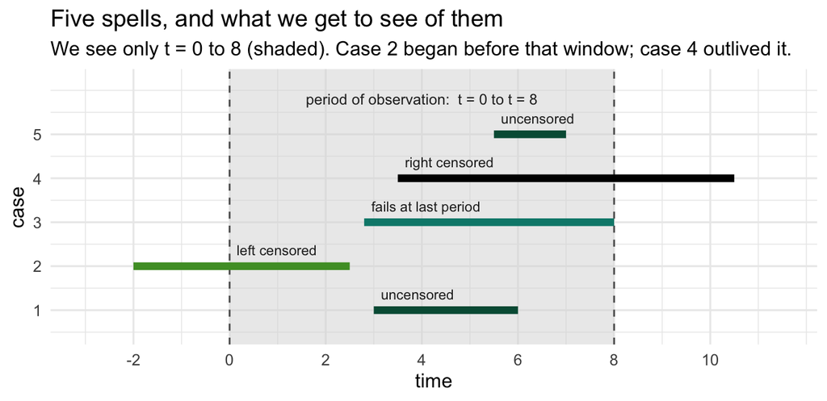

Figure 3

```r
# We observe t = 0 to t = 8 and nothing outside it. Two spells deliberately run
# past an edge: case 2 begins before 0, case 4 is still going after 8.
spells <- tibble(
  case  = 1:5,
  start = c(3.0, -2.0, 2.8,  3.5, 5.5),
  end   = c(6.0,  2.5, 8.0, 10.5, 7.0),
  kind  = c("uncensored", "left censored", "fails at last period",
            "right censored", "uncensored"))

ggplot(spells, aes(y = case)) +
  annotate("rect", xmin = 0, xmax = 8, ymin = -Inf, ymax = Inf,
           fill = "grey85", alpha = 0.5) +
  annotate("segment", x = c(0, 8), xend = c(0, 8), y = -Inf, yend = Inf,
           linetype = "dashed", color = "grey35", linewidth = 0.5) +
  annotate("text", x = 4, y = 5.8, label = "period of observation:  t = 0 to t = 8",
           hjust = 0.5, size = 3.2, color = "grey15") +
  geom_segment(aes(x = start, xend = end, yend = case, color = kind),
               linewidth = 2.2, lineend = "butt") +
  geom_text(aes(x = pmax(start, 0) + 0.15, label = kind), hjust = 0, vjust = -1.1,
            size = 3.0, color = "grey15") +
  scale_color_manual(values = c("uncensored" = bu_green,
                                "left censored" = bu_lightgreen,
                                "fails at last period" = bu_teal,
                                "right censored" = bu_black),
                     guide = "none") +
  scale_x_continuous(breaks = c(-2, 0, 2, 4, 6, 8, 10), limits = c(-3, 11.5)) +
  scale_y_continuous(breaks = 1:5, limits = c(0.5, 6.2)) +
  labs(title = "Five spells, and what we get to see of them",
       subtitle = "We see only t = 0 to 8 (shaded). Case 2 began before that window; case 4 outlived it.",
       x = "time", y = "case") +
  theme_bu()
```

The same data can be reshaped so that a row is a *spell* rather than a dyad-year. US–Cuba has three spells across eleven years at risk: two ending in disputes, and a third that simply runs out when our observation window closes.

```r
tibble(
  Dyad     = c("US--Cuba", "US--Cuba", "US--Cuba", "US--UK"),
  Year     = c(1961, 1967, 1970, 1967),
  Fail     = c(1, 1, 0, 0),
  Censored = c(0, 0, 1, 1),
  Survival = c(2, 6, 3, 8)
) %>%
  kbl(caption = "The same data as spells. Survival times sum to time at risk.") %>%
  kable_styling("striped", full_width = FALSE, font_size = 16)
```

The same data as spells. Survival times sum to time at risk.

| Dyad | Year | Fail | Censored | Survival |
| --- | --- | --- | --- | --- |
| US--Cuba | 1961 | 1 | 0 | 2 |
| US--Cuba | 1967 | 1 | 0 | 6 |
| US--Cuba | 1970 | 0 | 1 | 3 |
| US--UK | 1967 | 0 | 1 | 8 |

# The quantities

Write the probability of failing exactly at $t$ — the density:

$$f(t) = Pr(t_i = t)$$

The cumulative probability of having failed by $t$:

$$F(t) = \sum_{i=1}^{t} f(t_i)$$

The probability of surviving past $t$ is its complement, the **survivor function**:

$$S(t) = 1 - F(t) = Pr(t_i > t)$$

And the one we actually want — failing at $t$ *given* survival to $t$:

$$\begin{aligned}
h(t) &= Pr(t_i = t \mid t_i \geq t)\\
&= \frac{f(t)}{S(t-1)}
\end{aligned}$$

The denominator is $S(t-1)$, not $S(t)$: the units at risk in period $t$ are the ones who got *through* period $t-1$, which is what $S(t-1)$ counts. $S(t)$ has already removed the units that fail at $t$ — the very ones the hazard is about.

This is the **hazard rate**, the probability of failure at $t$, given survival until $t$. It explicitly relates the past to the present, which is how memory gets into the model. $h(t)$ differs from $Pr(y_t = 1)$ precisely by conditioning on what came before $t$.

Two rearrangements we will need. The conditional probability of surviving a period is one minus the hazard,

$$Pr(t_j > t \mid t_j \geq t) = 1 - h(t),$$

so the survivor function is the product of surviving each period up to $t$:

$$S(t) = \prod_{j=0}^{t}\left\{1 - h(j)\right\}$$

and the density factors as

$$f(t) = h(t)\,S(t-1).$$

## A likelihood

Build a likelihood out of those parts — failures contribute $f(t)$, survivors contribute $S(t)$:

$$\mathcal{L} = \prod_{t_i \leq t} f(t_i) \prod_{t_i \geq t} S(t_i)$$

Now let $y_{i,t}$ indicate whether a unit fails during our observation window (1) or is censored (0), and use it as a switch:

$$\mathcal{L} = \prod_{t_i \leq t} f(t_i)^{y_{i,t}} \prod_{t_i \geq t} S(t_i)^{1 - y_{i,t}}$$

That should look familiar — it is the same construction as the Bernoulli log-likelihood, one term for each outcome (survival, failure), with the exponent selecting which one applies. Substituting $f(t) = h(t)S(t)$:

$$\mathcal{L} = \prod_{i=1}^{N} \Bigg\{h(t)\prod_{j=1}^{t-1}\left[1 - h(t-j)\right]\Bigg\}^{y_{i,t}} \Bigg\{\prod_{j=0}^{t-1}\left[1 - h(t-j)\right]\Bigg\}^{1 - y_{i,t}}$$

Pick a form for the hazard and you have a model. The exponential gives a constant hazard, $h(t) = \lambda$; the Weibull gives $h(t) = \lambda p(\lambda t)^{p-1}$, monotonic in $t$. We take those up with continuous time models in November. In discrete time we do something easier.

### Both families maximize this same likelihood

Go back to the two ways of writing time. The likelihood above looks like it belongs to the continuous-time family: it is written one term per *spell*, and survival time appears in it directly. So it’s worth seeing why the discrete-time logit — which is written one row per *year*, with a 0/1 outcome — ends up maximizing the very same thing.

Take one leader who held office four years and then lost power. In person-period form that is four rows, and the model treats each as its own coin flip: did the spell end this year? Multiply the four probabilities together, since they are conditional on one another in sequence:

$$\underbrace{\left[1-h(1)\right]}_{\text{survived yr 1}} \times \underbrace{\left[1-h(2)\right]}_{\text{survived yr 2}} \times \underbrace{\left[1-h(3)\right]}_{\text{survived yr 3}} \times \underbrace{h(4)}_{\text{failed in yr 4}}$$

Now compare that with what the likelihood above asks for. A failure contributes $f(t) = h(t)S(t)$ — the chance of surviving to year four and then failing in it. **Those are the same expression.** The run of $[1-h(j)]$ terms *is* $S(t)$, and the last term is the hazard at failure. A censored leader — one still in office when the data stop — contributes only the run of survival terms, with no hazard on the end, which is exactly $S(t)$ on its own.

So the two families are not two models. They are **one likelihood, written two ways**, and each way keeps both halves of the story: survival time and failure. The continuous-time version puts survival time in the row and hides the failure indicator in the exponent; the discrete-time version puts the failure indicator in the row and hides survival time in *how many rows the spell gets*.

Why bother with the second one, then? Because of what the reshaping buys. A product over years becomes a sum over rows once we take logs, and a sum over rows with a binary outcome is precisely what a logit maximizes. **The discrete-time hazard model is not an approximation to a duration model — it is a duration model, laid out so that `glm` can estimate it.** That is the whole trick, and it is why the rest of this lecture can proceed with a tool you already know.

# Discrete-time hazards

Until the late 1990s, work on BTSCS data mostly ignored all of this: the conventional model was a plain logit, exactly like the memoryless dispute model above. Beck, Katz, and Tucker (1998) pointed out what was wrong with that, and proposed a fix simple enough that it became standard almost immediately.

**The problem.** A logit on these data assumes observations on $y$ arise independently — as if each dyad-year were its own Bernoulli trial, with no relationship between the outcome at $t$ and outcomes at $t-1, t-2, \ldots$. In the democratic peace context that means the chance of a dispute this year is unrelated to whether the dyad has been at peace for one year or for thirty. On its face that is a heroic assumption, and if it is wrong, the model is misspecified and the estimates are biased.

**The solution.** At its root, this is a specification problem: we think time since the last dispute matters, and no measure of it is in the model. So put one in. Beck, Katz, and Tucker suggest including **survival time** as a right-hand-side variable, and including nonlinear functions of it so the effect of time is not forced to be monotonic. They used survival time and cubic splines (nonlinear functions of survival time); Carter and Signorino (2010) later showed that polynomials in survival time do the same work and are far easier to compute and explain.

**The result.** Including survival time is now the state of the art, and it changes what the model’s predictions mean. They are no longer unconditional probabilities. They are conditional on survival — that is, they are **hazards**. Most published BTSCS models include survival time; rather fewer interpret the quantities of interest correctly.

## Building survival time

The counter is a within-dyad row number that resets after every dispute.

```r
survivaldp <- dp %>%
  arrange(dyad, year) %>%
  group_by(dyad) %>%
  # a new spell starts the year after a dispute; the first year of a dyad is
  # treated as though it followed one, since we cannot see before the window
  mutate(prior = lag(dispute, default = 1),
         spell = cumsum(prior == 1)) %>%
  group_by(dyad, spell) %>%
  mutate(stime = row_number() - 1) %>%
  ungroup() %>%
  dplyr::select(-prior, -spell) %>%
  mutate(stime2 = stime^2, stime3 = stime^3)

survivaldp %>%
  filter(dyad == first(dyad)) %>%
  dplyr::select(dyad, year, dispute, stime) %>%
  head(20) %>%
  kbl(caption = "Survival time in the democratic peace data: the counter resets at each dispute.") %>%
  kable_styling("striped", full_width = FALSE, font_size = 16)
```

Survival time in the democratic peace data: the counter resets at each dispute.

| dyad | year | dispute | stime |
| --- | --- | --- | --- |
| 2020 | 1951 | 0 | 0 |
| 2020 | 1952 | 0 | 1 |
| 2020 | 1953 | 0 | 2 |
| 2020 | 1954 | 0 | 3 |
| 2020 | 1955 | 0 | 4 |
| 2020 | 1956 | 0 | 5 |
| 2020 | 1957 | 0 | 6 |
| 2020 | 1958 | 0 | 7 |
| 2020 | 1959 | 0 | 8 |
| 2020 | 1960 | 0 | 9 |
| 2020 | 1961 | 0 | 10 |
| 2020 | 1962 | 0 | 11 |
| 2020 | 1963 | 0 | 12 |
| 2020 | 1964 | 0 | 13 |
| 2020 | 1965 | 0 | 14 |
| 2020 | 1966 | 0 | 15 |
| 2020 | 1967 | 0 | 16 |
| 2020 | 1968 | 0 | 17 |
| 2020 | 1969 | 0 | 18 |
| 2020 | 1970 | 0 | 19 |

Survival time runs from 0 to 34 years, averaging 11.5. About 8% of dyad-years sit at `stime == 0`, the year immediately after a dispute.

## Visualizing the risk set, $h(t)$, and $S(t)$

We’ve seen the definitions of $f(t)$, $S(t)$ and $h(t)$, but they’re also things we can construct pretty easily really by counting. This will help make the ideas more concrete.

We’ll build them on the leader data first, where a unit fails once and the arithmetic is easy to follow. The next section runs the same four lines on the dispute data, where units can fail more than once.

### Computing the quantities

Four steps. Each one produces a column in the table below, and the code folded under each figure *is* that step. I’ve truncated the figures at 25 years just for presentation; a few spells run longer.

**1. Group the person-period rows by survival time $t$.** Every leader-year with $t=3$ goes in one group, every leader-year with survival time of $t=4$ in the next. We are sorting rows by how long the spell had already run when the row was recorded. One bar per group, and the height is how many rows fell into it:

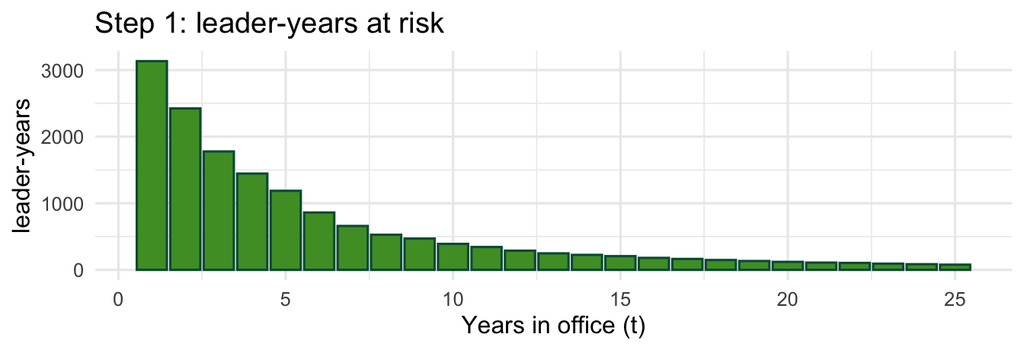

Figure 4

```r
ggplot(dplyr::filter(lt, t <= 25), aes(t)) +
  geom_bar(fill = bu_lightgreen, color = bu_green) +
  labs(title = "Step 1: leader-years at risk",
       x = "Years in office (t)", y = "leader-years") +
  theme_bu()
```

**2. Count the rows in each group. That is the risk set at $t$** — the units that survived to $t$ and could still fail there. It is the denominator of the hazard: the $S(t-1)$ in $h(t) = f(t)/S(t-1)$, written as a count instead of a probability. In person-period data you get it by counting rows, because a leader who left office in year three *has no row for year four* — the spell is over, so it stops generating rows. Same for a censored leader: the data stop, so the rows stop. That count is the `at_risk` column in the table below, and Figure 4 already draws it — the height of each bar is the number of leader-years that reached $t$ and could still fail there.

**3. Sum the failures in each group, and divide.** Failures over rows at risk is $\hat h(t)$ — of those who reached year $t$, the share who left during it. This is the definition we wrote earlier,

$$h(t) = Pr(t_i = t \mid t_i \geq t),$$

with counts standing in for probabilities: the numerator counts the units that failed *at* $t$, the denominator counts everyone who made it *to* $t$. The denominator is what makes this conditional since it counts only the units that were still around at $t$. These are the `failures` and `h` columns in the table.

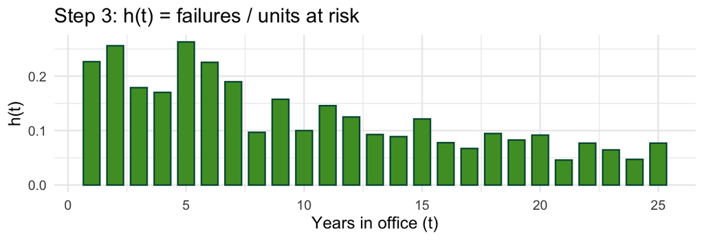

Figure 5

```r
lt %>%
  group_by(t) %>%
  summarise(h = mean(leftoffice), .groups = "drop") %>%   # failures / rows at risk
  dplyr::filter(t <= 25) %>%
  ggplot(aes(t, h)) +
  geom_col(fill = bu_lightgreen, color = bu_green, width = 0.7) +
  labs(title = "Step 3: h(t) = failures / units at risk",
       x = "Years in office (t)", y = "h(t)") +
  theme_bu()
```

**4. Take the running product of the complements.** $1 - \hat h(t)$ is the share who got through year $t$ having reached it, so multiplying them from the first year on gives $\hat S(t)$, the share who got through all of them. That is the other formula we wrote earlier,

$$S(t) = \prod_{j=0}^{t}\left\{1 - h(t-j)\right\},$$

done arithmetically. These are the `one_minus_h` and `S` columns. One line more than step 3 — the `cumprod()`:

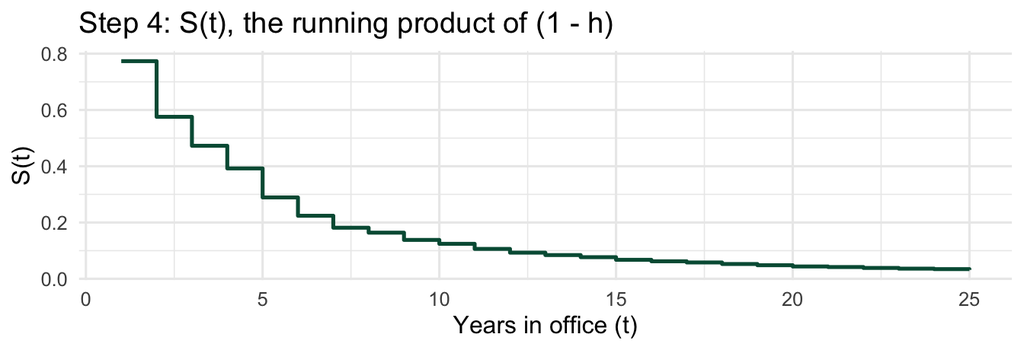

Figure 6

```r
lt %>%
  group_by(t) %>%
  summarise(h = mean(leftoffice), .groups = "drop") %>%
  mutate(S = cumprod(1 - h)) %>%                          # chain the complements
  dplyr::filter(t <= 25) %>%
  ggplot(aes(t, S)) +
  geom_step(color = bu_green, linewidth = 0.9) +
  labs(title = "Step 4: S(t), the running product of (1 - h)",
       x = "Years in office (t)", y = "S(t)") +
  theme_bu()
```

Let’s follow these four steps and compute the six quantities below. Doing so is straightforward, using `group_by()`, `summarise()`, one division, and `cumprod()`.

```r
emp_lt <- lt %>%
  group_by(t) %>%                                            # step 1
  summarise(at_risk = n(),                                   # step 2
            failures = sum(leftoffice), .groups = "drop") %>%
  mutate(h = failures / at_risk,                             # step 3
         one_minus_h = 1 - h,
         S = cumprod(one_minus_h))                           # step 4

emp_lt %>%
  head(6) %>%
  mutate(across(h:S, ~ round(.x, 3))) %>%
  kbl(caption = "The hazard and survivor functions, by counting. Leader-years, first six years of tenure.") %>%
  kable_styling("striped", full_width = FALSE, font_size = 16)
```

The hazard and survivor functions, by counting. Leader-years, first six years of tenure.

| t | at_risk | failures | h | one_minus_h | S |
| --- | --- | --- | --- | --- | --- |
| 1 | 3134 | 710 | 0.227 | 0.773 | 0.773 |
| 2 | 2424 | 620 | 0.256 | 0.744 | 0.576 |
| 3 | 1778 | 318 | 0.179 | 0.821 | 0.473 |
| 4 | 1446 | 246 | 0.170 | 0.830 | 0.392 |
| 5 | 1187 | 312 | 0.263 | 0.737 | 0.289 |
| 6 | 861 | 194 | 0.225 | 0.775 | 0.224 |

Let’s work through the first two rows. 3,134 leader-years sit at $t=1$, and 710 of those leaders left during their first year, so $\hat h(1) = 710/3134 = 0.227$ and $\hat S(1) = 1 - 0.227 = 0.773$. Of the 2,424 who reached a second year, 620 went, so $\hat h(2) = 620/2424 = 0.256$ — and the share surviving *two* years is $0.773 \times 0.744 = 0.576$. Notice the risk set fell from 3,134 to 2,424: the 710 who failed are gone. From year two to year three it falls by 646 while only 620 failed; the other 26 are spells that stop without failing — censored, or leader-years the Polity join dropped.

This is the discrete-time cousin of the Kaplan–Meier estimator, and it is what a hazard model is trying to describe. It has no covariates in it, which is both its virtue — nothing can be mis-specified — and its limit, since it cannot tell you what democracy does. That is what the models are for. But it gives us a picture of the thing being modeled, and something to check a model against.

Three things to take from the figures.

**The risk set drains over time** (Figure 4). We start with 3,134 leader-years at $t=1$ and are down to 78 by year 25. Units leave the risk set by failing *or* by being censored, and either way they stop contributing. This is why hazard estimates get noisy at long survival times — not because the model is bad, but because by then there is almost nobody left to learn from. Any confidence band you see widening out to the right is telling you about this picture.

**The hazard is not monotonic** (Figure 5). The first eight years run 0.23, 0.26, 0.18, 0.17, 0.26, 0.23, 0.19, 0.10: **high, and wandering.** The riskiest year of the eight is the fifth, not the first, and the series goes up and down twice before it starts falling in earnest. Whatever is going on in leader tenure, “risk decays with time survived” is not a fair summary of it.

**$S(t)$ chains the hazards over time** (Figure 6). Multiply the complements and you get the share still surviving: about 58% of leaders make it through two years, 47% through three, and only about 3% are still in office 25 years on.

None of this involved a model. That matters twice over: it means the hazard is a real feature of data rather than an artifact of a specification, and it gives us something to check a model *against* — which we do as soon as we have one.

## The same quantities for the dispute data

The leader data are the simple case: a leader takes office once, leaves once, and the spell is over. Dyads are not like that. The United States and Russia can have a dispute, settle, stay quiet for years, and have another one — and in these data they do that repeatedly. Two things change before we run the recipe again.

**Units fail more than once, so the clock restarts.** We do not follow a dyad across the whole window as a single spell. Every dispute ends a spell, and the year after it begins a new one with the counter back at the start. That is what the `cumsum()` in the survival-time code was doing. The 827 dyads here generate **1,735 spells**; 203 dyads contribute more than one, and the US–Russia dyad alone contributes 33 — its clock restarts 32 times. So the risk set at $t$ counts *spells* that reached $t$, not dyads. The leader data do the same thing in a less obvious way: a leader who returns to office gets a new Archigos id, and the clock starts over.

**The counter starts at 0, not 1.**

### Why leaders start at 1 and disputes start at 0

The two counters measure different things.

- The leader counter is **time in office, counting the current year**. A leader’s first year is year 1. There is no year 0, because every leader in the data occupies a first year — the clock starts when they take office, and taking office is not a failure.
- The dyad counter is **years of peace already banked before the current one** — Beck, Katz, and Tucker (1998)’s “peace years.” The clock here is started *by* a failure, and the year immediately after a dispute has no full year of peace behind it. So it is 0. At $t=1$ one year of peace has elapsed, at $t=2$ two, and so on.

Two consequences. First, a clock that gets restarted by failures needs a value meaning “just failed,” and that value is 0. It is also where most of the failures are: 593 of the 1,735 spells fail at $t=0$. Second, every dyad’s *first observed* year is coded 0 too. The code sets `lag(dispute, default = 1)`, which treats the start of the window as though a dispute had just happened. We cannot see before 1951, so we assume the clock was just reset. This is a lousy assumption. A better practice would be to count back to the last dispute prior to 1951 (and many scholars do this since the dispute data are readily available back to 1815).

Starting at zero versus one does not change the model. A cubic in $t$ is also a cubic in $t+1$ — shifting the origin is absorbed by the polynomial’s coefficients, and the fit is identical. What it changes is how you *read* the numbers: “the hazard at $t=1$” means a leader’s first year in office, but a dyad’s second year of peace.

### Doing the counting

Nothing about the code changes except variable names. Group by `stime` instead of `t`, and sum `dispute` instead of `leftoffice`:

```r
emp_dp <- survivaldp %>%
  group_by(t = stime) %>%
  summarise(at_risk = n(), failures = sum(dispute), .groups = "drop") %>%
  mutate(h = failures / at_risk,
         one_minus_h = 1 - h,
         S = cumprod(one_minus_h))

emp_dp %>%
  head(6) %>%
  mutate(across(h:S, ~ round(.x, 3))) %>%
  kbl(caption = "Dispute data. Dyad spells, first six years of peace.") %>%
  kable_styling("striped", full_width = FALSE, font_size = 16)
```

Dispute data. Dyad spells, first six years of peace.

| t | at_risk | failures | h | one_minus_h | S |
| --- | --- | --- | --- | --- | --- |
| 0 | 1735 | 593 | 0.342 | 0.658 | 0.658 |
| 1 | 1120 | 64 | 0.057 | 0.943 | 0.621 |
| 2 | 1045 | 50 | 0.048 | 0.952 | 0.591 |
| 3 | 984 | 47 | 0.048 | 0.952 | 0.563 |
| 4 | 930 | 25 | 0.027 | 0.973 | 0.548 |
| 5 | 888 | 16 | 0.018 | 0.982 | 0.538 |

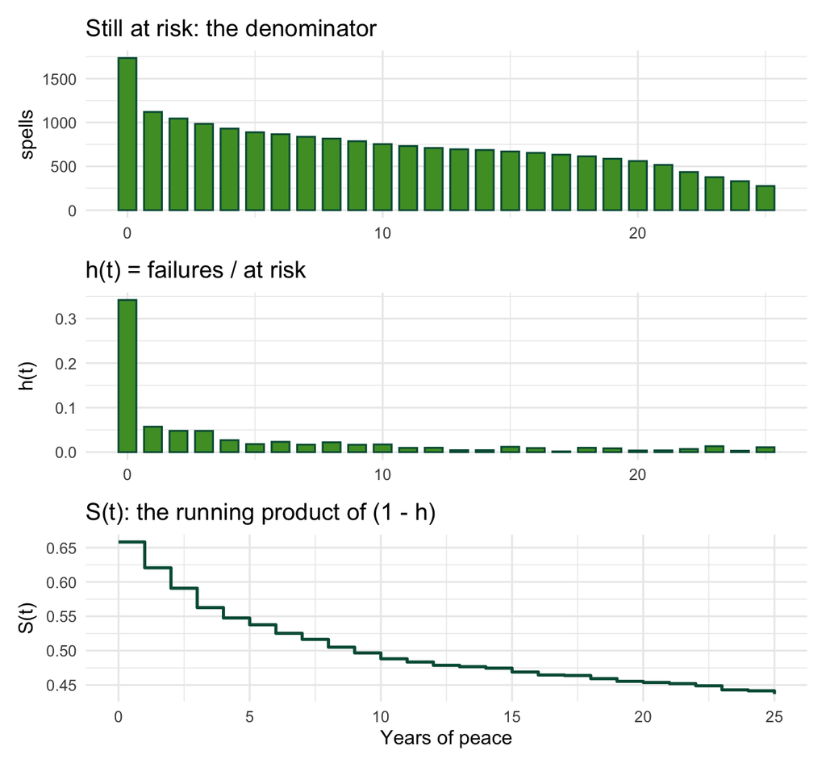

Figure 7

```r
emp_dp25 <- emp_dp %>% dplyr::filter(t <= 25)

d_risk <- ggplot(emp_dp25, aes(t, at_risk)) +
  geom_col(fill = bu_lightgreen, color = bu_green, width = 0.7) +
  labs(title = "Still at risk: the denominator", x = NULL, y = "spells") + theme_bu()

d_haz <- ggplot(emp_dp25, aes(t, h)) +
  geom_col(fill = bu_lightgreen, color = bu_green, width = 0.7) +
  labs(title = "h(t) = failures / at risk", x = NULL, y = "h(t)") + theme_bu()

d_surv <- ggplot(emp_dp25, aes(t, S)) +
  geom_step(color = bu_green, linewidth = 0.9) +
  labs(title = "S(t): the running product of (1 - h)",
       x = "Years of peace", y = "S(t)") + theme_bu()

d_risk / d_haz / d_surv
```

You can see the hazard is shaped nothing like the hazard from the leaders data. It’s $593/1735 = 0.342$ in the year right after a dispute and $64/1120 = 0.057$ the year after that — barely a sixth the size, in a single step — then it grinds down under 0.02 and stays there. Disputes beget disputes, and the danger passes quickly. Because the hazard collapses so fast, $S(t)$ flattens early: about 44% of spells are still at peace 25 years on, against 3% of leaders still in office. The risk set drains here too, from 1,735 spells to 275, so as with the leader data, we’d expect wider confidence intervals as we move further out on survival time.

**Important point**

All of this rests on knowing our data extremely well, and on telling the software exactly what we know. R cannot intuit what these rows mean. It cannot tell that `obsid` is a spell while `leadid` is a person, that the counter restarts after every dispute but never after a leader takes office, that a zero on the last row of a spell is a censored case rather than a survival, or that one dyad contributes 33 spells. We have to say all of it: what the unit is, what time is counted from, what counts as a failure, whether units can fail more than once, and which spells are censored.

That is both the power of these models and the burden of using them. The power is that the structure carries real information — the risk set, the censoring, the restarting clock — and the model puts it to work. The burden is that we supply the structure by hand and nothing checks us. Get it wrong and the estimates still come back, with standard errors, looking perfectly reasonable. When the data structure is not specified carefully, these models lose their meaning fast.

## Three baseline hazards

The three models below differ only in how much freedom the baseline hazard has.

**Constant.** With no time term, the baseline hazard is a single number:

$$h_0(t) = \frac{1}{1 + \exp(-\beta_0)}$$

and the $x$ variables shift everything around that constant. This is the memoryless dispute model, and it is the flat line in Figure 1.

**Monotonic.** Add the survival counter and the baseline can rise or fall, but only in one direction:

$$h_0(t) = \frac{1}{1 + \exp[-(\beta_0 + \gamma_0 t)]}$$

**Non-monotonic.** Add $t^2$ and $t^3$ and the baseline is free to fall, flatten, and rise again:

$$h_0(t) = \frac{1}{1 + \exp[-(\beta_0 + \gamma_0 t + \gamma_1 t^2 + \gamma_2 t^3)]}$$

The other two are special cases of this one: set $\gamma_1 = \gamma_2 = 0$ and the baseline is monotonic; set all three $\gamma$s to zero and it is constant. This is a close approximation to a Cox proportional-hazards model: it nests the constant (exponential) and monotonic (Weibull) hazards, it is very general, and it is trivial to estimate.

```r
h_const <- glm(dispute ~ border + deml + lncaprat + ally,
               family = binomial(link = "logit"), data = survivaldp)
h_mono  <- glm(dispute ~ stime,
               family = binomial(link = "logit"), data = survivaldp)
h_cubic <- glm(dispute ~ stime + stime2 + stime3,
               family = binomial(link = "logit"), data = survivaldp)
h_full  <- glm(dispute ~ stime + stime2 + stime3 + border + deml + lncaprat + ally,
               family = binomial(link = "logit"), data = survivaldp)

modelsummary(list("constant, with X" = h_const, "monotonic" = h_mono,
                  "cubic" = h_cubic, "cubic + X" = h_full),
             stars = TRUE,
             coef_rename = c("stime" = "Survival time", "stime2" = "Survival time^2",
                             "stime3" = "Survival time^3", "border" = "Shared border",
                             "deml" = "Min. democracy",
                             "lncaprat" = "Capabilities ratio (log)", "ally" = "Allied"),
             gof_omit = "RMSE|F",
             title = "Dispute models: four baseline hazards, Oneal-Russett dyad-years.")
```

Dispute models: four baseline hazards, Oneal-Russett dyad-years.

|  | constant, with X | monotonic | cubic | cubic + X |
| --- | --- | --- | --- | --- |
| (Intercept) | -2.987*** | -1.513*** | -0.950*** | -0.664*** |
|  | (0.107) | (0.045) | (0.048) | (0.121) |
| Shared border | 1.036*** |  |  | 0.487*** |
|  | (0.088) |  |  | (0.094) |
| Min. democracy | -0.070*** |  |  | -0.055*** |
|  | (0.007) |  |  | (0.007) |
| Capabilities ratio (log) | -0.227*** |  |  | -0.262*** |
|  | (0.024) |  |  | (0.025) |
| Allied | -0.842*** |  |  | -0.562*** |
|  | (0.081) |  |  | (0.088) |
| Survival time |  | -0.265*** | -0.830*** | -0.780*** |
|  |  | (0.010) | (0.035) | (0.035) |
| Survival time^2 |  |  | 0.052*** | 0.048*** |
|  |  |  | (0.004) | (0.004) |
| Survival time^3 |  |  | -0.001*** | -0.001*** |
|  |  |  | (0.000) | (0.000) |
| Num.Obs. | 20990 | 20990 | 20990 | 20990 |
| AIC | 7024.3 | 6208.1 | 5742.6 | 5367.2 |
| BIC | 7064.1 | 6224.0 | 5774.4 | 5430.8 |
| Log.Lik. | -3507.152 | -3102.041 | -2867.307 | -2675.594 |

+ p < 0.1, * p < 0.05, ** p < 0.01, *** p < 0.001

Take a look at the second column. **Survival time alone — one variable, two parameters — fits these data far better than all four substantive covariates together.** Log-likelihood $-3102$ against $-3507$; AIC $6208$ against $7024$. Those two models are not nested — neither is a restricted version of the other — so this is an AIC comparison, not a likelihood-ratio test.

The nested comparison we *can* test is the last column against the first: the cubic baseline added to the same four covariates.

```r
# Cubic baseline against constant baseline, same covariates in both.
anova(h_const, h_full, test = "LRT")
```

```
Analysis of Deviance Table

Model 1: dispute ~ border + deml + lncaprat + ally
Model 2: dispute ~ stime + stime2 + stime3 + border + deml + lncaprat +
    ally
  Resid. Df Resid. Dev Df Deviance  Pr(>Chi)
1     20985     7014.3
2     20982     5351.2  3   1663.1 < 2.2e-16 ***
---
Signif. codes:  0 '***' 0.001 '**' 0.01 '*' 0.05 '.' 0.1 ' ' 1
```

$\chi^2 = 1663.1$ on 3 degrees of freedom, and the log-likelihood moves from $-3507$ to $-2676$. Three survival-time terms do a great deal of work in a model that already has the four substantive covariates in it.

## The baseline hazards

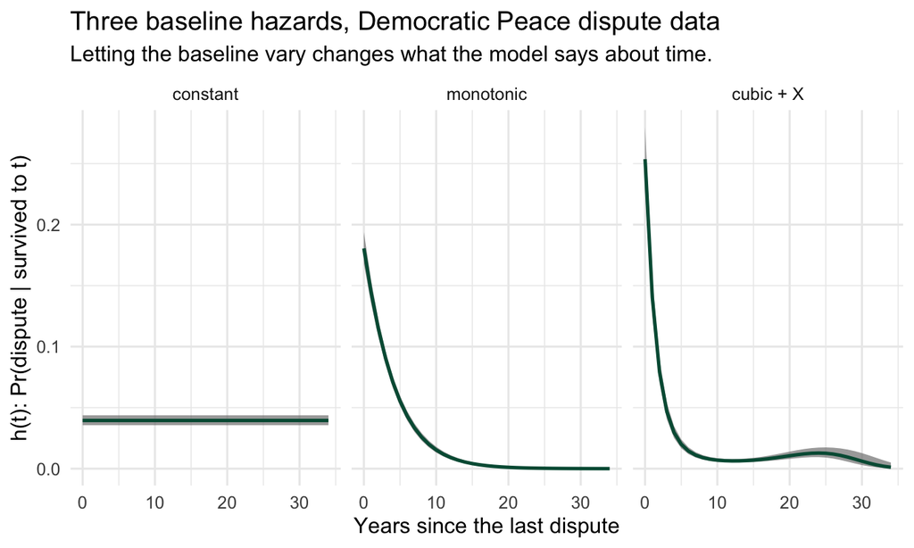

Figure 8

```r
grid <- tibble(stime = 0:34) %>%
  mutate(stime2 = stime^2, stime3 = stime^3,
         border = 0, deml = median(survivaldp$deml),
         lncaprat = median(survivaldp$lncaprat), ally = 0)

haz <- function(m, lab) {
  p <- predict(m, newdata = grid, type = "link", se.fit = TRUE)
  tibble(model = lab, stime = grid$stime,
         h  = plogis(p$fit),
         lb = plogis(p$fit - 1.96 * p$se.fit),
         ub = plogis(p$fit + 1.96 * p$se.fit))
}

bind_rows(haz(h_const, "constant"), haz(h_mono, "monotonic"), haz(h_full, "cubic + X")) %>%
  mutate(model = factor(model, levels = c("constant", "monotonic", "cubic + X"))) %>%
  ggplot(aes(stime, h)) +
  geom_ribbon(aes(ymin = lb, ymax = ub), fill = bu_greyfill, alpha = 0.7) +
  geom_line(color = bu_green, linewidth = 0.9) +
  facet_wrap(~ model) +
  labs(title = "Three baseline hazards, Democratic Peace dispute data",
       subtitle = "Letting the baseline vary changes what the model says about time.",
       x = "Years since the last dispute", y = "h(t): Pr(dispute | survived to t)") +
  theme_bu()
```

The cubic hazard starts at about **0.25** in the year right after a dispute, falls to **0.14** by the next year and **0.02** by year five, bottoms out near **0.007** around year ten, and drifts back up slightly after that. That shape is what the model is telling us: **disputes beget disputes, and the risk decays fast.** A model without time reports a flat 4% for all of it, which is close to right on average and wrong nearly everywhere.

## Covariates as shifts of the baseline

With the baseline free to vary, the $x$ variables are deviations from it. Here is democracy, at three values - these are average effects plotted across survival time. Note the y-axis is labeled h(t) - still just a logit model and the same prediction we’ve learned to generate, but because we’re computing the probability of failure **given** survival, this is now the hazard rate of disputes.

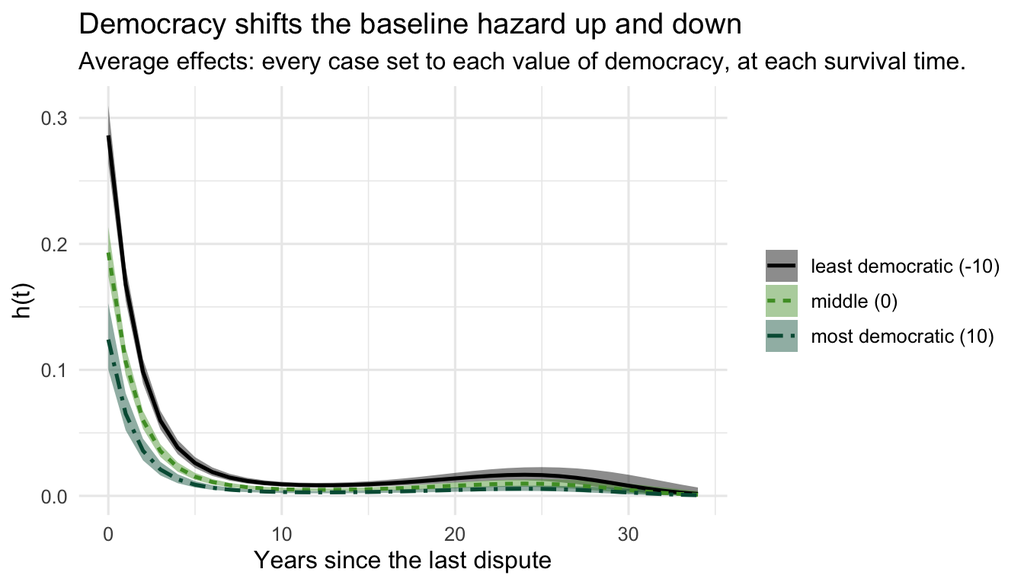

Figure 9

```r
esample <- survivaldp %>% drop_na(dispute, stime, border, deml, lncaprat, ally)

bh <- coef(h_full)
Vh <- vcov(h_full)

# The quantity is the AVERAGE hazard at (deml, t): one number, a function of
# beta-hat. Its gradient is the average of the case-level gradients, so the
# delta method gives its standard error directly. Averaging the case-level
# standard errors instead would describe a typical dyad, not the average -- and
# a symmetric band on the probability scale runs below zero once the hazard is
# near the floor, so bound the linear predictor and transform the end points.
avg_hazard <- function(d_value) {
  map_dfr(0:34, function(t) {
    nd <- esample %>% mutate(deml = d_value, stime = t, stime2 = t^2, stime3 = t^3)
    X  <- model.matrix(formula(h_full)[-2], data = nd)
    xb <- as.vector(X %*% bh)
    hbar <- mean(plogis(xb))
    g  <- colMeans(sweep(X, 1, dlogis(xb), "*"))
    se <- sqrt(as.numeric(t(g) %*% Vh %*% g))
    tibble(deml = d_value, stime = t, h = hbar,
           lo = plogis(qlogis(hbar) - 1.96 * se / (hbar * (1 - hbar))),
           hi = plogis(qlogis(hbar) + 1.96 * se / (hbar * (1 - hbar))))
  })
}

hd <- map_dfr(c(-10, 0, 10), avg_hazard) %>%
  mutate(democracy = factor(deml, levels = c(-10, 0, 10),
                            labels = c("least democratic (-10)", "middle (0)",
                                       "most democratic (10)")))

ggplot(hd, aes(stime, h, color = democracy, fill = democracy, linetype = democracy)) +
  geom_ribbon(aes(ymin = lo, ymax = hi), alpha = 0.45, color = NA) +
  geom_line(linewidth = 0.9) +
  scale_color_manual(values = c(bu_black, bu_lightgreen, bu_green)) +
  scale_fill_manual(values = c(bu_black, bu_lightgreen, bu_green)) +
  # the dash pattern repeats what the color says, so the three curves stay
  # separable in greyscale, on a washed-out projector, and for a reader with a
  # color vision deficiency (WCAG 1.4.1)
  scale_linetype_manual(values = bu_lty[1:3]) +
  labs(title = "Democracy shifts the baseline hazard up and down",
       subtitle = "Average effects: every case set to each value of democracy, at each survival time.",
       x = "Years since the last dispute", y = "h(t)",
       # all three of color/fill/linetype must be NULL-titled or ggplot draws
       # the redundant aesthetic as a SECOND legend instead of merging it in
       color = NULL, fill = NULL, linetype = NULL) +
  theme_bu()
```

Look at what the three curves do. They share a shape, and democracy moves them up or down — that is what “proportional hazards” means - this is an important feature of many hazard models and we’ll address it later in the semester.

The model specification also matters for the coefficient we estimate. Democracy’s estimate moves from $-0.070$ in the memoryless model to $-0.055$ once we include survival time — about a fifth of the apparent democratic-peace effect was time dependence being attributed to democracy.

# Modeling leader tenure

Everything above was built on dyad-years, where a dyad fights, makes peace, and can fight again. That is a **repeated-events** setting, and it is why the survival counter had to reset: one dyad contributes several spells. Plenty of processes do not work that way. A leader leaves office once, and the spell is over — there is nothing to reset.

So take the same machinery to leader tenure. The data are leader-years built from Archigos (Goemans, Gleditsch, and Chiozza 2009): one row per year a leader held office, and `leftoffice` marking the year the spell ends. The regime measure is `polity2` from Polity V, available at [Center for Systemic Peace](https://www.systemicpeace.org/inscrdata.html). Two features to notice before any model.

**Censored observations.** 168 leaders were still in power when Archigos stopped collecting on 31 December 2015. Their spells have not ended; we simply stopped watching. Those leader-years belong in the risk set with `leftoffice = 0`, exactly like the right-censored case in Figure 3. Code them as exits and you manufacture 168 failures that never happened.

**Survival time counts within the spell, not within the leader.** The spell identifier is `obsid`; `leadid` identifies the *person*. There are 3,409 spells among 2,802 leaders, so 457 people held office more than once, and grouping by the person joins their separate spells into one long tenure — counting the years they were out of office as though they were in it.

```r
lt %>%
  filter(obsid %in% c("USA-1961", "USA-1963")) %>%
  dplyr::select(obsid, leader, year, t, leftoffice, exitreason) %>%
  kbl(caption = "Leader-years: survival time restarts with each spell, and the exit lands on the last row.") %>%
  kable_styling("striped", full_width = FALSE, font_size = 16)
```

Leader-years: survival time restarts with each spell, and the exit lands on the last row.

| obsid | leader | year | t | leftoffice | exitreason |
| --- | --- | --- | --- | --- | --- |
| USA-1961 | Kennedy | 1961 | 1 | 0 | Irregular |
| USA-1961 | Kennedy | 1962 | 2 | 0 | Irregular |
| USA-1961 | Kennedy | 1963 | 3 | 1 | Irregular |
| USA-1963 | Johnson | 1963 | 1 | 0 | Regular |
| USA-1963 | Johnson | 1964 | 2 | 0 | Regular |
| USA-1963 | Johnson | 1965 | 3 | 0 | Regular |
| USA-1963 | Johnson | 1966 | 4 | 0 | Regular |
| USA-1963 | Johnson | 1967 | 5 | 0 | Regular |
| USA-1963 | Johnson | 1968 | 6 | 0 | Regular |
| USA-1963 | Johnson | 1969 | 7 | 1 | Regular |

Now the same three baselines, on the same specification we would use without any of this.

```r
l_const <- glm(leftoffice ~ polity2 + age + female + entry + region,
               family = binomial(link = "logit"), data = lt)
l_mono  <- glm(leftoffice ~ t + polity2 + age + female + entry + region,
               family = binomial(link = "logit"), data = lt)
l_cubic <- glm(leftoffice ~ t + t2 + t3 + polity2 + age + female + entry + region,
               family = binomial(link = "logit"), data = lt)

modelsummary(list("constant" = l_const, "monotonic" = l_mono, "cubic" = l_cubic),
             stars = TRUE,
             coef_rename = c("t" = "Survival time", "t2" = "Survival time^2",
                             "t3" = "Survival time^3", "polity2" = "Polity",
                             "age" = "Leader age", "female" = "Female",
                             "entryIrregular" = "Irregular entry",
                             "entryForeign Imposition" = "Foreign imposition"),
             coef_omit = "region", gof_omit = "RMSE|F",
             fmt = fmt_significant(3),
             title = "Leader survival models: three baseline hazards, Archigos leader-years.",
             notes = "Regional fixed effects estimated, not shown. Baseline: Europe.")
```

Leader survival models: three baseline hazards, Archigos leader-years.

|  | constant | monotonic | cubic |
| --- | --- | --- | --- |
| (Intercept) | -2.291*** | -2.350*** | -2.35*** |
|  | (0.114) | (0.115) | (0.12) |
| Polity | 0.05397*** | 0.04066*** | 0.03889*** |
|  | (0.00363) | (0.00385) | (0.00386) |
| Leader age | 0.01595*** | 0.02167*** | 0.02205*** |
|  | (0.00188) | (0.00197) | (0.00198) |
| Female | -0.332* | -0.327* | -0.326* |
|  | (0.152) | (0.152) | (0.152) |
| Irregular entry | 0.3942*** | 0.4081*** | 0.4109*** |
|  | (0.0611) | (0.0614) | (0.0615) |
| Foreign imposition | -0.0281 | 0.0338 | 0.0677 |
|  | (0.2250) | (0.2260) | (0.2266) |
| Survival time |  | -0.03857*** | -0.0300+ |
|  |  | (0.00393) | (0.0155) |
| Survival time^2 |  |  | -0.00221* |
|  |  |  | (0.00109) |
| Survival time^3 |  |  | 5.89e-05** |
|  |  |  | (1.86e-05) |
| Num.Obs. | 16068 | 16068 | 16068 |
| AIC | 14762.3 | 14654.3 | 14630.1 |
| BIC | 14839.1 | 14738.8 | 14730.0 |
| Log.Lik. | -7371.138 | -7316.134 | -7302.034 |

+ p < 0.1, * p < 0.05, ** p < 0.01, *** p < 0.001  
Regional fixed effects estimated, not shown. Baseline: Europe.

The time terms are jointly a large improvement — a likelihood-ratio test of the cubic against the constant baseline gives $\chi^2 = 138.2$ on 3 degrees of freedom — but look at what happens to the covariates. **Polity falls from $0.054$ to $0.039$, about 28%, and leader age rises from $0.0159$ to $0.0221$, about 38%.**

```r
# The likelihood-ratio test quoted above: cubic baseline against constant.
anova(l_const, l_cubic, test = "LRT")
```

```
Analysis of Deviance Table

Model 1: leftoffice ~ polity2 + age + female + entry + region
Model 2: leftoffice ~ t + t2 + t3 + polity2 + age + female + entry + region
  Resid. Df Resid. Dev Df Deviance  Pr(>Chi)
1     16058      14742
2     16055      14604  3   138.21 < 2.2e-16 ***
---
Signif. codes:  0 '***' 0.001 '**' 0.01 '*' 0.05 '.' 0.1 ' ' 1
```

Age is the instructive one. Age and tenure are correlated by construction — a leader gets a year older for every year in office — so in a model with no measure of tenure, `age` is measuring two things at once, and doing a poor job of both. Part of its coefficient is the effect of being an older person; part of it is the effect of having been in office a while. The two work against each other: older leaders are more likely to go, while leaders who have already survived several years are less likely to. And the longer a leader has been in office, the more of their age is tenure rather than the age they arrived with — so the more age stands in for survival time, and the more its own effect is diminished. That is the $0.0159$ in the constant-baseline model.

Adding survival time separates the two. Tenure gets its own terms, age is left with its own effect, and the estimate rises to $0.0221$. The general point: whenever a covariate is mechanically correlated with time in the spell, leaving the baseline hazard unmodeled makes that covariate absorb the duration dependence instead.

## Comparing hazards: Leaders and Disputes

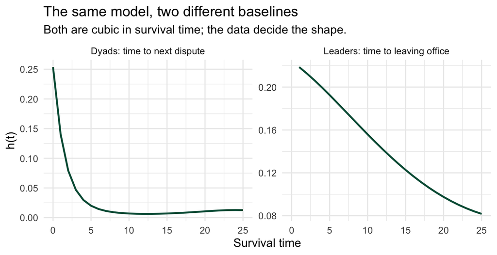

Figure 10

```r
dp_shape <- tibble(stime = 0:25) %>%
  mutate(stime2 = stime^2, stime3 = stime^3, border = 0,
         deml = median(survivaldp$deml), lncaprat = median(survivaldp$lncaprat), ally = 0) %>%
  mutate(h = plogis(predict(h_full, newdata = .)), data = "Dyads: time to next dispute")

lt_shape <- map_dfr(1:25, function(tt) {
  d <- lt %>% mutate(t = tt, t2 = tt^2, t3 = tt^3)
  tibble(stime = tt, h = mean(predict(l_cubic, newdata = d, type = "response")))
}) %>% mutate(data = "Leaders: time to leaving office")

bind_rows(dp_shape %>% dplyr::select(stime, h, data), lt_shape) %>%
  ggplot(aes(stime, h)) +
  geom_line(color = bu_green, linewidth = 0.9) +
  facet_wrap(~ data, scales = "free_y") +
  labs(title = "The same model, two different baselines",
       subtitle = "Both are cubic in survival time; the data decide the shape.",
       x = "Survival time", y = "h(t)") +
  theme_bu()
```

Both hazards fall, and the way they fall is completely different. The dyad hazard **collapses**: a quarter in the year after a dispute, 2% by year five, and 0.7% by year ten — a thirty-seventh of where it started. The leader hazard **decays gently and stays substantial**: 0.22 in the first year, 0.19 at five, 0.16 at ten, still 0.08 at twenty-five. Roughly a third of its starting value after a quarter century, where the dyads got there inside three years.

That difference is substantive. A dispute is a shock that fades — having survived a few years of peace, a dyad is nearly out of danger, and the risk is concentrated right after the last fight. Holding office is not like that. Every year in power carries a real chance of losing it, and surviving a decade buys you a lower risk but nothing like safety.

**The polynomial does not impose either shape; it permits both.** We’ve relaxed the assumption the models are memoryless, or that the baseline hazard is constant. By doing so, we’ve relaxed the assumption that the effects of the $X$ variables do not change over time. The models and predictions here show both assumptions are wrong and pretty consequential.

## Do estimated hazards match the data?

We now have a fitted baseline for each dataset, and from earlier we have the raw hazard each is trying to describe. Put them on the same axes. The bars are `failures / at risk`, straight from the data; the line is the model’s average fitted hazard at each survival time.

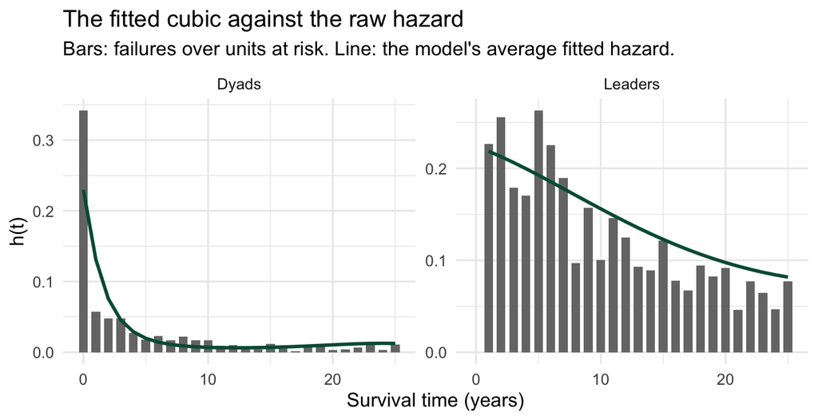

Figure 11

```r
emp <- bind_rows(emp_dp %>% mutate(data = "Dyads"),
                 emp_lt %>% mutate(data = "Leaders")) %>%
  dplyr::filter(t <= 25)

es_dp <- survivaldp %>% drop_na(dispute, stime, border, deml, lncaprat, ally)

fit_dp <- map_dfr(0:25, function(tt) tibble(t = tt, data = "Dyads",
  h = mean(predict(h_full, newdata = mutate(es_dp, stime = tt, stime2 = tt^2, stime3 = tt^3),
                   type = "response"))))

fit_lt <- map_dfr(1:25, function(tt) tibble(t = tt, data = "Leaders",
  h = mean(predict(l_cubic, newdata = mutate(lt, t = tt, t2 = tt^2, t3 = tt^3),
                   type = "response"))))

ggplot(emp, aes(t, h)) +
  # raw data in neutral grey, model in BU green: the bars carry data so they
  # need a 3:1 color, but a saturated green bar outweighs the fitted line and
  # inverts the hierarchy the subtitle describes
  geom_col(fill = bu_grey, width = 0.7) +
  geom_line(data = bind_rows(fit_dp, fit_lt), aes(t, h), color = bu_green, linewidth = 1) +
  facet_wrap(~ data, scales = "free_y") +
  labs(title = "The fitted cubic against the raw hazard",
       subtitle = "Bars: failures over units at risk. Line: the model's average fitted hazard.",
       x = "Survival time (years)", y = "h(t)") +
  theme_bu()
```

Comparing the estimated hazard to the data directly is a good practice - here’s what we learn:

**Where it works.** The polynomial tracks the dyads’ collapse well from year one onward, and it gets the leaders’ overall level and gentle decline about right.

**Where it does not.** Look at year zero in the dispute panel: the raw hazard is **0.34** and the fitted line reaches only **0.23**. A smooth cubic cannot turn that sharply — it has to approach the spike from somewhere, and in doing so it flattens it. The leader panel shows the mirror-image problem: the raw series bounces between 0.10 and 0.26 through the middle years, and the cubic runs straight through the middle of the bouncing, reading 0.16 at year ten where the data say 0.10.

Neither of those is scandalous, but both point to parts of the hazard we’re not explaining well. What might this tell us in terms of model specification? In the leaders model, the spikes between years 5-8 could be driven in part by democratic electoral cycles; we didn’t include anything to that effect in the model. In the dispute model, the spike in the first year after a dispute could tell us something about the nature of rivalry, and perhaps we need to measure rival dyads.

# Presenting hazard results

Here is the practical problem with everything above. A hazard is a conditional probability at a point in time, and it is genuinely hard to talk about. “The hazard is 0.153 at $t=1$” tells a reader almost nothing they can hold onto. What they want to know is how long leaders last, and how much longer they last under one condition than another.

The good news is that the survivor function gets you there, and we already derived it; here’s the process for turning coefficients into something more useful for interpretation:

**First, the average hazard at each $t$.** Fix a value of the covariate you care about — say Polity $= -10$ — and assign it to *every leader-year in the estimation sample*, leaving each case’s own age, gender, route to power and region alone. Predict, and average those predictions. That gives $\bar h(t)$: the annual risk of exit for a typical leader-year in these data, under that counterfactual. Repeat for each $t$ from 1 to 25, and for each Polity value.

**Then chain the complements.** Surviving to $t$ means not failing in year 1, *and* not failing in year 2, *and* so on. Each of those is a conditional probability, so they multiply:

$$S(t) = \prod_{j \le t}\left\{1 - \bar h(j)\right\}$$

$1 - \bar h(j)$ is the chance of getting through year $j$ having reached it, and the running product is the chance of getting through all of them. **Nothing new is estimated at this step.** $S(t)$ is arithmetic on hazards we already have, which is why the two panels below come from one model and why they have to tell a consistent story.

**Uncertainty by simulation.** $S(t)$ is a product of twenty-five hazards, each a nonlinear function of $\widehat\beta$, and a first-order Taylor expansion is a poor approximation to it. King–Tomz–Wittenberg’s simulation approach is the right one.

```r
set.seed(20260916)   # the draws below are the whole engine; fix the seed here so
                     # the simulated quantities do not move with chunk order
TMAX  <- 25
sims  <- MASS::mvrnorm(1000, coef(l_cubic), vcov(l_cubic))

# Average hazard at each t, once per simulated coefficient vector.
# colMeans, not rowMeans: we want the mean across CASES within a draw, which is
# one realization of the average hazard. Averaging across draws within a case
# would describe the spread of predictions across leaders instead.
haz_draws <- function(p) {
  sapply(1:TMAX, function(tt) {
    d <- lt %>% mutate(polity2 = p, t = tt, t2 = tt^2, t3 = tt^3)
    X <- model.matrix(formula(l_cubic)[-2], data = d)
    colMeans(plogis(X %*% t(sims)))
  }) %>% t()                                     # TMAX x 1000
}

H <- lapply(c(-10, 0, 10), haz_draws)            # hazards
S <- lapply(H, function(M) apply(M, 2, function(col) cumprod(1 - col)))   # survivors
names(H) <- names(S) <- c("-10", "0", "10")

band <- function(M, p, what) {
  tibble(polity = p, t = 1:TMAX, what = what,
         est = apply(M, 1, median),
         lo  = apply(M, 1, quantile, 0.025),
         hi  = apply(M, 1, quantile, 0.975))
}
```

## 1. The hazard, and 2. the survivor function

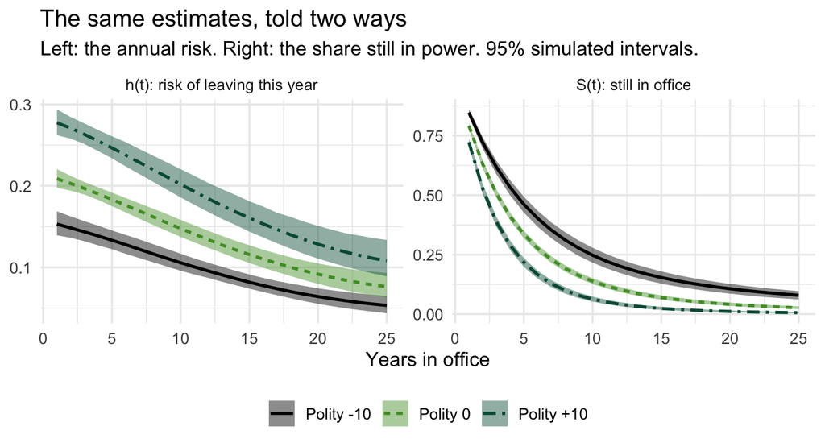

Figure 12

```r
qi <- bind_rows(
  bind_rows(Map(function(M, p) band(M, p, "h(t): risk of leaving this year"), H, c(-10, 0, 10))),
  bind_rows(Map(function(M, p) band(M, p, "S(t): still in office"), S, c(-10, 0, 10)))
) %>%
  mutate(polity = factor(polity, levels = c(-10, 0, 10),
                         labels = c("Polity -10", "Polity 0", "Polity +10")),
         # facet_wrap orders character values alphabetically, which would put
         # S(t) on the left; the prose reads hazard first, so fix the order
         what = factor(what, levels = c("h(t): risk of leaving this year",
                                        "S(t): still in office")))

ggplot(qi, aes(t, est, color = polity, fill = polity, linetype = polity)) +
  geom_ribbon(aes(ymin = lo, ymax = hi), alpha = 0.45, color = NA) +
  geom_line(linewidth = 0.9) +
  facet_wrap(~ what, scales = "free_y") +
  scale_color_manual(values = c(bu_black, bu_lightgreen, bu_green)) +
  scale_fill_manual(values = c(bu_black, bu_lightgreen, bu_green)) +
  scale_linetype_manual(values = bu_lty[1:3]) +
  labs(title = "The same estimates, told two ways",
       subtitle = "Left: the annual risk. Right: the share still in power. 95% simulated intervals.",
       x = "Years in office", y = NULL, color = NULL, fill = NULL, linetype = NULL) +
  theme_bu() +
  theme(legend.position = "bottom")
```

**The left panel is $h(t)$, the hazard.** Each point is the average annual probability that a leader who has already served $t$ years leaves office during year $t$. It is a *rate*, and it is conditional twice over — on having survived to $t$, and on the counterfactual Polity value. Read it and you learn that in a first year, leaders in the most democratic states face about a 0.28 chance of going and leaders in the most autocratic about 0.15, and that both risks decay slowly: 0.20 against 0.11 by year ten. Every curve slopes down, so in both kinds of state having survived a while makes a leader somewhat safer.

What the left panel does **not** tell you is how long anybody lasts. Thirteen percentage points of annual rate is not a quantity most readers can convert into anything.

**The right panel is $S(t)$, the survivor function.** Each point is the share of leaders who have *not yet* left after $t$ years — the running product just above. It starts near one, can only fall, and the same estimates that looked merely different on the left separate sharply here, because a per-year gap compounds every year a leader survives:

- after five years, **46%** of leaders in the most autocratic states are still in power against **22%** in the most democratic;
- after ten, **25%** against **6%**.

Now put the panels together and say what these data imply. **Democratic leaders in this sample are not slightly more replaceable — they are roughly four times less likely to still be in office a decade on.** Elections recur, and each one is another chance to lose; autocracies have no such schedule, so a leader who consolidates can stay. Both panels contain that claim. Only the right one makes it legible.

Neither panel adds information to the other. The right one reports a better-chosen quantity.

## 3. Median survival time

The survivor curve compressed to one number per scenario.

**How it is computed.** Go along $S(t)$ and find the first year in which it falls below 0.5 — the year by which half the leaders in that counterfactual are gone. Do it *inside each simulated draw*, so the interval reflects uncertainty about the whole curve rather than about one point on it, then take the median and the 2.5th and 97.5th percentiles across the 1,000 draws.

**What it means.** The tenure of the median leader, not the average leader — a duration, in years. Being a median it is unbothered by the long tail, which matters in these data, where a handful of monarchs served for decades and would drag a mean around.

```r
med_draw <- function(M) apply(M, 2, function(col) {
  w <- which(col < 0.5); if (length(w)) w[1] else NA_integer_
})

tibble(Polity = c(-10, 0, 10)) %>%
  mutate(m = map(S, med_draw),
         `Median tenure (yrs)` = map_dbl(m, median, na.rm = TRUE),
         `95% interval` = map_chr(m, ~ sprintf("[%.0f, %.0f]",
                                   quantile(.x, .025, na.rm = TRUE),
                                   quantile(.x, .975, na.rm = TRUE)))) %>%
  dplyr::select(-m) %>%
  kbl(caption = "Median time in office, by regime type.") %>%
  kable_styling("striped", full_width = FALSE, font_size = 16)
```

Median time in office, by regime type.

| Polity | Median tenure (yrs) | 95% interval |
| --- | --- | --- |
| -10 | 5 | [4, 5] |
| 0 | 4 | [3, 4] |
| 10 | 3 | [3, 3] |

**Five years against three.** Half the leaders in a closed autocracy are gone by five years; in a full democracy, half are gone within three. That is the whole model in one comparison, and it is the number a reader will remember — you could put it in an abstract, which is true of nothing in the coefficient table.

Two caveats. The data are annual, so the median is read off a yearly grid and comes out an integer, and the interval inherits that coarseness. And this is a property of the *counterfactual*, not of any actual group of leaders: it says what these 16,068 leader-years imply for a leader whose Polity score is held at $-10$ while everything else about them stays as observed. The hazard figure, the survivor figure and this number are three reports of the same estimates.

# Competing risks

Every model so far has treated “leaving office” as one event. It is not. A leader can lose an election, or be removed at gunpoint, and lumping the two together assumes the process that produces one also produces the other. Archigos records how each spell ended, so we can evaluate that assumption.

A **competing risks** model estimates a separate hazard for each kind of exit, and the mechanics are simpler than the name suggests. **The sample does not change. The covariates do not change. The risk set does not change. What changes is $y$.**

Archigos records a reason for every exit, so we can build one 0/1 outcome per cause. `reg` is 1 in the year a leader left through regular channels and 0 in every other leader-year. `irr` is 1 in the year a leader was removed irregularly and 0 in every other leader-year. Both are still binary, both are still estimated with an ordinary logit, and both run on the same 16,068 leader-years.

**Recoding $y$ is how we recode the censoring.** Take a leader deposed in year six. In the irregular-exit model that row is a 1 — a failure. In the regular-exit model the same row is a 0, and the 0 does not mean they survived year six. It means they did not fail *from that cause*. They still leave the risk set — there is no row for year seven either way — so what the 0 records is a censored spell.

Here is the recoding itself, one row per kind of exit Archigos records:

```r
# Same rows, same covariates, same risk set -- the only thing that changes is y.
#
# leftoffice was built on the full file, before the Polity join dropped rows, so
# split it by cause here rather than recomputing "last year" inside the joined
# sample -- a spell whose final year the join dropped would otherwise have its
# last SURVIVING year mislabeled as the exit.
cr <- lt %>%
  mutate(reg = as.integer(leftoffice == 1 & exitreason == "Regular"),
         irr = as.integer(leftoffice == 1 & exitreason == "Irregular"))

# Two logits, same right-hand side, same data. Only the outcome differs.
m_reg <- glm(reg ~ t + I(t^2) + I(t^3) + polity2 + age + female + entry + region,
             family = binomial(link = "logit"), data = cr)

m_irr <- glm(irr ~ t + I(t^2) + I(t^3) + polity2 + age + female + entry + region,
             family = binomial(link = "logit"), data = cr)

cr %>%
  dplyr::filter(leftoffice == 1) %>%
  count(`Exit recorded` = exitreason,
        `y, regular exit model` = reg,
        `y, irregular exit model` = irr,
        name = "leader-years") %>%
  arrange(desc(`leader-years`)) %>%
  kbl(caption = "The same 2,996 exits, coded two ways. Everything not coded 1 is censored.") %>%
  kable_styling("striped", full_width = FALSE, font_size = 16)
```

The same 2,996 exits, coded two ways. Everything not coded 1 is censored.

| Exit recorded | y, regular exit model | y, irregular exit model | leader-years |
| --- | --- | --- | --- |
| Regular | 1 | 0 | 2151 |
| Irregular | 0 | 1 | 566 |
| Natural Death | 0 | 0 | 178 |
| Retired Due to Ill Health | 0 | 0 | 64 |
| Foreign | 0 | 0 | 35 |
| Suicide | 0 | 0 | 2 |

Note what the table shows at the bottom. Of the 2,996 exits, 2,151 are regular and 566 irregular — which leaves **279 that are neither**: natural deaths, retirements for ill health, foreign removals, two suicides. Those rows are 0 in *both* models, which means we have declared them censored for both causes. That is a choice we made, not a fact about the data, and the alternative is a third cause-specific model. It is exactly the kind of thing the software cannot decide for us.

Leader survival models by cause of exit, Archigos leader-years.

|  | regular exit | irregular exit |
| --- | --- | --- |
| Survival time | -0.0227 | -0.0587+ |
|  | (0.0222) | (0.0309) |
| Survival time^2 | -0.00311 | -0.00129 |
|  | (0.00194) | (0.00204) |
| Survival time^3 | 4.53e-05 | 5.55e-05+ |
|  | (4.05e-05) | (3.31e-05) |
| Polity | 0.07392*** | -0.07304*** |
|  | (0.00477) | (0.00859) |
| Leader age | 0.02004*** | 0.01028** |
|  | (0.00235) | (0.00398) |
| Female | -0.267+ | -0.126 |
|  | (0.160) | (0.461) |
| Irregular entry | 0.146+ | 0.7373*** |
|  | (0.084) | (0.0963) |
| Foreign imposition | -0.167 | -0.181 |
|  | (0.322) | (0.513) |
| (Intercept) | -2.594*** | -4.494*** |
|  | (0.142) | (0.264) |
| Num.Obs. | 16068 | 16068 |
| Log.Lik. | -5650.687 | -2262.973 |
| AIC | 11327.4 | 4551.9 |

+ p < 0.1, * p < 0.05, ** p < 0.01, *** p < 0.001  
Cause-specific hazards. In each column, exits from every other cause are treated as censored. Regional fixed effects estimated, not shown.

## Polity effects

Look at the Polity row, and then look at the estimate from the pooled model.

| model | Polity coefficient |
| --- | --- |
| leaving office, any cause | $+0.039$ |
| **regular exit** | $\mathbf{+0.074}$ |
| **irregular exit** | $\mathbf{-0.073}$ |

**Equal and opposite, and both estimated precisely** ($z = 15.5$ and $-8.5$). Democracy makes a leader much more likely to leave through regular channels and much less likely to be removed by force. Those are two mechanisms pulling in two directions, and the pooled model — which reported $+0.039$ — is reporting their weighted average. It is not that the pooled estimate is imprecise. It is that there is no single quantity for it to estimate.

**What the pooled model was actually estimating**

Not “the effect of democracy on losing power.” Something closer to “the effect of democracy on losing power, averaged over a mix of two processes whose composition is itself a function of democracy.” That is not a quantity anyone set out to learn about.

## Cumulative incidence: the right prediction here

The survivor function still works — with two causes, the chance of surviving year $j$ is $1 - \bar h_{\text{reg}}(j) - \bar h_{\text{irr}}(j)$, since either failure ends the spell. But the question a competing-risks model asks is *how* leaders leave, and for that we want the **cumulative incidence function**: the probability of having left by time $t$ *from cause $k$*.

$$\text{CIF}_k(t) = \sum_{j \le t} \bar h_k(j)\, S(j-1)$$

To exit from cause $k$ in year $j$ you must first still be in office at the start of year $j$ — that is $S(j-1)$ — and then fail from cause $k$ — that is $\bar h_k(j)$. Sum over the years and you get the share who have gone that way by $t$. **This is why you cannot just run $1 - S_k(t)$ on a single cause and call it the probability of that exit:** doing so pretends the other cause never removes anyone from the risk set, and the two “probabilities” then exceed one.

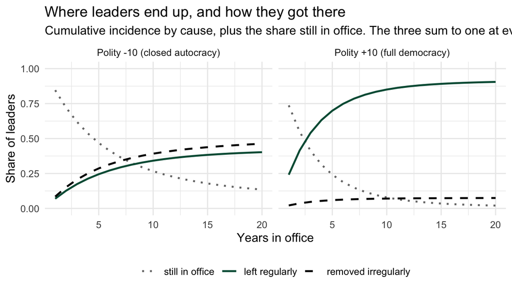

Figure 13

```r
# No R package computes the CIF for DISCRETE-time, person-period data, so we do
# the arithmetic by hand. For CONTINUOUS time there are two:
#
#   cmprsk    cmprsk::cuminc() -- the nonparametric (Aalen-Johansen) CIF, with
#             variances, and Gray's test for comparing groups
#   survival  survival::survfit() with a factor status variable gives the same
#             estimator; survival::finegray() + coxph() fits the Fine-Gray
#             subdistribution model
#
# Neither takes a person-period logit, and neither returns the covariate-
# conditional average we want here.
#
# No intervals on these curves. Doing that properly means one joint model rather
# than two separate logits -- a multinomial logit on {still in office, regular
# exit, irregular exit}, which is what a discrete-time competing-risks model
# really is -- and then KTW simulation with the whole CIF computed inside each
# draw, so the three curves still sum to one in every draw. We leave that for
# the multinomial and continuous-time weeks later in the course.
cif <- function(p) {
  ah <- function(m, tt) mean(predict(m, newdata = mutate(cr, polity2 = p, t = tt),
                                     type = "response"))
  hR <- sapply(1:20, function(tt) ah(m_reg, tt))
  hI <- sapply(1:20, function(tt) ah(m_irr, tt))
  Sv <- cumprod(1 - hR - hI)                 # survive BOTH risks
  tibble(polity = p, t = 1:20,
         `left regularly`   = cumsum(hR * c(1, head(Sv, -1))),
         `removed irregularly` = cumsum(hI * c(1, head(Sv, -1))),
         `still in office`  = Sv)
}

cr_pred <- map_dfr(c(-10, 10), cif)


cr_pred %>%
  pivot_longer(-c(polity, t), names_to = "outcome", values_to = "p") %>%
  mutate(outcome = factor(outcome, levels = c("still in office", "left regularly",
                                              "removed irregularly")),
         polity = factor(polity, levels = c(-10, 10),
                         labels = c("Polity -10 (closed autocracy)",
                                    "Polity +10 (full democracy)"))) %>%
  ggplot(aes(t, p, color = outcome, linetype = outcome)) +
  geom_line(linewidth = 0.9) +
  facet_wrap(~ polity) +
  scale_color_manual(values = c(bu_grey, bu_green, bu_black)) +
  scale_linetype_manual(values = c("dotted", "solid", "dashed")) +
  scale_y_continuous(limits = c(0, 1)) +
  labs(title = "Where leaders end up, and how they got there",
       subtitle = "Cumulative incidence by cause, plus the share still in office. The three sum to one at every t.",
       x = "Years in office", y = "Share of leaders", color = NULL, linetype = NULL) +
  theme_bu() +
  theme(legend.position = "bottom")
```

The three curves in each panel sum to one at every $t$, as they must - the proportion of leaders still in office plus those removed irregularly, plus those removed regularly must sum to one. Look at what we learn that we couldn’t from the pooled model.

**Twenty years in office in a closed autocracy: 40% of leaders have left regularly, 46% have been removed irregularly, and 13% are still in power.** A leader in that setting is *more likely to be deposed than to leave through regular channels*.

**In a full democracy: 91% left regularly, 7% were removed irregularly, 2% remain.**

We’re not just learning that democratic turnover is faster than in non-democratic states. It is that **democracy changes the mix of exits, not just the rate.** Autocratic leaders do not merely last longer; the way they leave is different in kind, and in a closed autocracy it is close to a coin flip which of the two it is. Averaging those two exits into one $y$ variable throws away important and interesting variability.

**A caveat on independence**

Cause-specific hazards estimated this way assume the two risks are independent given the covariates — that whatever makes a coup more likely this year is not also, through some channel we have left out, making an election more likely. This is an assumption built into this type of competing risks structure; in most settings, scholars don’t even acknowledge it, and it’s not testable with these data.

# A different kind of memory: transition models

What if we simply lagged $y$, the way we might in OLS?

$$y_t = \beta_0 + \beta_1 x_1 + \ldots + \gamma y_{t-1} + \varepsilon$$

This is not a hazard model and doesn’t tell us anything at all about the difference between a dyad that’s been at peace for one year and a dyad that’s been at peace for 20 years. However both models are about memory, but they remember different things.

- A **hazard model** conditions on *how long the unit has been in its current state*. It asks: given that this dyad has been at peace for seven years, what is the chance of a dispute now?
- A **transition model** conditions on *which state the unit was in during the last period*. It asks: given that this dyad was fighting last year, what is the chance it is fighting now?

Neither is a substitute for the other, and which one you want is a claim about the process. Notice also that a transition model needs **recurrent states** — somewhere to transition back from. The leader data cannot support one: `leftoffice = 1` ends the spell. Dyads make peace and fight again continuously such that they are always in one state or another.

## Two probabilities the pooled logit averages together

With binary $y$ and a binary lag, there are only two conditional probabilities to estimate: the chance of a dispute given peace last year, and the chance of one given a dispute last year. Onset and continuation.

```r
trans <- survivaldp %>%
  arrange(dyad, year) %>%
  group_by(dyad) %>%
  mutate(lagy = lag(dispute)) %>%
  ungroup() %>%
  drop_na(lagy, dispute, border, deml, lncaprat, ally)

trans %>%
  group_by(`Last year` = if_else(lagy == 1, "dispute", "peace")) %>%
  summarise(`Dyad-years` = n(),
            `Pr(dispute this year)` = mean(dispute)) %>%
  mutate(`Pr(dispute this year)` = round(`Pr(dispute this year)`, 3)) %>%
  kbl(caption = "The two transition probabilities, straight from the data.") %>%
  kable_styling("striped", full_width = FALSE, font_size = 16)
```

The two transition probabilities, straight from the data.

| Last year | Dyad-years | Pr(dispute this year) |
| --- | --- | --- |
| dispute | 908 | 0.598 |
| peace | 19255 | 0.018 |

**1.8% against 59.8%.** A dyad at peace last year has under a two percent chance of a dispute; a dyad that was fighting has a better-than-even chance of still fighting. The pooled logit we started the lecture with reports a single number, about 4%, that is an average of these two and describes neither.

This is the same complaint we made about the memoryless model, arriving from a different direction. There the model ignored *duration*; here it ignores *state*.

## The effect of $x$ can depend on the state

Once the lag is in, there is no reason to expect a covariate to work the same way in both states. Contiguity might drive dyads into disputes without doing much to prolong them. So the transition model is naturally **interactive**:

$$Pr(y_{i,t} = 1) = F\!\left(x_{i,t}\beta + y_{i,t-1}\,x_{i,t}\gamma\right)$$

where $\gamma$ is the difference in $x$’s effect between the two states.

```r
t_add <- glm(dispute ~ lagy + border + deml + lncaprat + ally,
             family = binomial(link = "logit"), data = trans)
t_int <- glm(dispute ~ lagy * (border + deml + lncaprat + ally),
             family = binomial(link = "logit"), data = trans)

modelsummary(list("additive" = t_add, "interactive" = t_int),
             stars = TRUE,
             coef_rename = c("lagy" = "Dispute last year", "border" = "Shared border",
                             "deml" = "Min. democracy",
                             "lncaprat" = "Capabilities ratio (log)", "ally" = "Allied"),
             gof_omit = "RMSE|F",
             title = "Dispute transition models, Oneal-Russett dyad-years.",
             notes = "Interactions are with the lagged outcome.")
```

Dispute transition models, Oneal-Russett dyad-years.

|  | additive | interactive |
| --- | --- | --- |
| (Intercept) | -3.951*** | -4.459*** |
|  | (0.134) | (0.179) |
| Dispute last year | 4.048*** | 5.164*** |
|  | (0.089) | (0.296) |
| Shared border | 0.746*** | 1.380*** |
|  | (0.108) | (0.146) |
| Min. democracy | -0.046*** | -0.049*** |
|  | (0.008) | (0.010) |
| Capabilities ratio (log) | -0.128*** | -0.089* |
|  | (0.029) | (0.038) |
| Allied | -0.467*** | -0.355** |
|  | (0.101) | (0.120) |
| Dispute last year:Shared border |  | -1.498*** |
|  |  | (0.227) |
| Dispute last year:Min. democracy |  | 0.016 |
|  |  | (0.019) |
| Dispute last year:Capabilities ratio (log) |  | -0.015 |
|  |  | (0.065) |
| Dispute last year:Allied |  | -0.354+ |
|  |  | (0.201) |
| Num.Obs. | 20163 | 20163 |
| AIC | 4584.3 | 4511.3 |
| BIC | 4631.8 | 4590.4 |
| Log.Lik. | -2286.141 | -2245.645 |

+ p < 0.1, * p < 0.05, ** p < 0.01, *** p < 0.001  
Interactions are with the lagged outcome.

The interactions earn their place: a likelihood-ratio test gives $\chi^2 = 81.0$ on 4 degrees of freedom. The effect of $x$ genuinely does depend on the state.

```r
# The likelihood-ratio test quoted above: interactive against additive.
anova(t_add, t_int, test = "LRT")
```

```
Analysis of Deviance Table

Model 1: dispute ~ lagy + border + deml + lncaprat + ally
Model 2: dispute ~ lagy * (border + deml + lncaprat + ally)
  Resid. Df Resid. Dev Df Deviance  Pr(>Chi)
1     20157     4572.3
2     20153     4491.3  4   80.991 < 2.2e-16 ***
---
Signif. codes:  0 '***' 0.001 '**' 0.01 '*' 0.05 '.' 0.1 ' ' 1
```

And one interaction does nearly all the work. **Shared border** has a coefficient of $1.38$ for dyads at peace and $1.380 - 1.498 = -0.118$ for dyads already fighting.

```r
bt <- coef(t_int)
tibble(Variable = c("Shared border", "Min. democracy", "Capabilities ratio (log)", "Allied"),
       `In peace` = bt[c("border", "deml", "lncaprat", "ally")],
       `In dispute` = bt[c("border", "deml", "lncaprat", "ally")] +
                      bt[c("lagy:border", "lagy:deml", "lagy:lncaprat", "lagy:ally")]) %>%
  mutate(across(where(is.numeric), ~ round(.x, 3))) %>%
  kbl(caption = "The same coefficients, by the state the dyad was in last year.") %>%
  kable_styling("striped", full_width = FALSE, font_size = 16)
```

The same coefficients, by the state the dyad was in last year.

| Variable | In peace | In dispute |
| --- | --- | --- |
| Shared border | 1.380 | -0.118 |
| Min. democracy | -0.049 | -0.032 |
| Capabilities ratio (log) | -0.089 | -0.104 |
| Allied | -0.355 | -0.709 |

Contiguity is a powerful predictor of **starting** a dispute and essentially irrelevant to **continuing** one. That makes sense: neighbors have things to fight about, but once a dispute is underway, whether the two states share a border tells you little about whether it drags on. A pooled model reports one border coefficient and hides the distinction entirely.

Democracy moves the other way but not decisively — $-0.049$ in peace against $-0.032$ in dispute, and the interaction is nowhere near conventional significance ($p = 0.39$). The honest reading is that the pacifying effect we can see is about onset, and these data cannot tell us whether it also shortens disputes.

**Two models, two questions**

This is not a horse race. If your question is *when does a spell end*, you want a hazard: the baseline in survival time is the thing you are modeling. If your question is *what makes a unit change state*, you want transitions, and you probably want them interactive. Reporting a pooled logit answers neither and looks like it answered both.

# Summary

- We relaxed temporal independence, which every binary model up to now had assumed without comment.
- We did it by treating the quantity of interest as a **hazard** — a conditional probability — rather than an unconditional probability.
- The model that does this is a logit with a flexible function of survival time on the right-hand side, so the baseline hazard is estimated rather than assumed constant.
- The result has memory: the past shapes the present, and in these data it shapes it a lot. Survival time alone outperformed every substantive variable in the dispute model.
- The same machinery went to leader tenure without modification and found a completely different baseline — a slow decay rather than a collapse. Fitting the flexible baseline is how you learn which you have.
- **Report survivor functions, not just hazards.** A hazard at $t$ is hard to read; the share still surviving, and the median survival time, are the quantities a reader can use. Both fall out of the fitted hazards with one line of arithmetic, and simulation bounds them.
- **Competing risks** when the event has kinds. Splitting “left office” into regular and irregular exit turned one Polity coefficient of $+0.039$ into $+0.074$ and $-0.073$ — two mechanisms pulling opposite ways, which the pooled model had been averaging into a number that estimated neither. Report cumulative incidence, and check that the causes and the survivors sum to one.
- Transition models answer a different question — what makes a unit change state, rather than when a spell ends — and in the dispute data they show that contiguity drives onset and does nothing for continuation.

In November we come back to all of this in continuous time, where survival time is the dependent variable rather than a regressor.

[figure not shown]

Back to top

## References

Beck, Nathaniel, Jonathan M. Katz, and Richard Tucker. 1998. “Beyond Ordinary Logit: Taking Time Seriously in Binary Time-Series Cross-Section Models.” *American Journal of Political Science* 42 (4): 1260–88.

Carter, David B, and Curtis S Signorino. 2010. “Back to the Future: Modeling Time Dependence in Binary Data.” *Political Analysis* 18 (3): 271–92.

Goemans, Henk E., Kristian Skrede Gleditsch, and Giacomo Chiozza. 2009. “Introducing Archigos: A Dataset of Political Leaders.” *Journal of Peace Research* 46 (2): 269–83.

Oneal, John R., and Bruce M. Russett. 1997. “The Classic Liberals Were Right: Democracy, Interdependence, and Conflict, 1950-1985.” *International Studies Quarterly* 41 (2): 267–94.

## Footnotes

[^1]: I used Claude code to generate Figures 2 and 13.